# HE Assignment 8 - K-Means & DBSCAN

Eric Boyle, Quaidzoher Dhilla, Brandon Hyer, Will Kelly, Christian Mukania, and Vinh Tran

8/1/2021

## 1.0 - Load and prep the data

## Load packages and read in data

```r
library(tidyverse)
library(factoextra)
# Read in data
clustering_input1 <- read_rds("city.rds")
```

## Remove city, region, and province

```r
clustering_input2 <- clustering_input1 %>%
        select(-city, -region, -province)

str(clustering_input2)
```

```
## tibble [257 × 18] (S3: tbl_df/tbl/data.frame)
##  $ size                       : num [1:257] 762 1031 394 902 853 ...
##  $ promo_units_per            : num [1:257] 0.412 0.309 0.34 0.373 0.377 ...
##  $ high_med_gp                : num [1:257] 0.631 1 0 0.981 0.604 ...
##  $ velocityA_units_per        : num [1:257] 0.62 0.594 0.688 0.608 0.63 ...
##  $ velocityB_units_per        : num [1:257] 0.216 0.227 0.209 0.233 0.221 ...
##  $ velocityC_units_per        : num [1:257] 0.0729 0.0903 0.0381 0.0761 0.0683 ...
##  $ velocityD_units_per        : num [1:257] 0.0772 0.079 0.0571 0.0715 0.0673 ...
##  $ velocityNEW_units_per      : num [1:257] 0.00346 0.00217 0.0027 0.00219 0.0048 ...
##  $ energy_units_per           : num [1:257] 0.14 0.17 0.16 0.17 0.176 ...
##  $ regularBars_units_per      : num [1:257] 0.0948 0.0683 0.1067 0.0664 0.0884 ...
##  $ gum_units_per              : num [1:257] 0.05 0.0296 0.0703 0.0404 0.064 ...
##  $ bagpegCandy_units_per      : num [1:257] 0.0436 0.0292 0.0223 0.0433 0.0364 ...
##  $ isotonics_units_per        : num [1:257] 0.0603 0.0529 0.1019 0.0635 0.0592 ...
##  $ singleServePotato_units_per: num [1:257] 0.0323 0.0443 0.0325 0.0313 0.0347 ...
##  $ takeHomePotato_units_per   : num [1:257] 0.0227 0.0221 0 0.0244 0.02 ...
##  $ kingBars_units_per         : num [1:257] 0.0412 0.04 0.0735 0.0352 0.0396 ...
##  $ flatWater_units_per        : num [1:257] 0.0985 0.1116 0.0885 0.1041 0.0884 ...
##  $ psd591Ml_units_per         : num [1:257] 0.0347 0.0509 0.057 0.0537 0.0287 ...
```

```r
summary(clustering_input2)
```

```
##       size        promo_units_per   high_med_gp     velocityA_units_per
##  Min.   : 297.0   Min.   :0.2198   Min.   :0.0000   Min.   :0.5129
##  1st Qu.: 679.2   1st Qu.:0.3355   1st Qu.:0.1154   1st Qu.:0.6189
##  Median : 782.5   Median :0.3688   Median :0.5504   Median :0.6378
##  Mean   : 758.0   Mean   :0.3678   Mean   :0.5399   Mean   :0.6412
##  3rd Qu.: 869.8   3rd Qu.:0.3954   3rd Qu.:0.9904   3rd Qu.:0.6638
##  Max.   :1119.0   Max.   :0.5541   Max.   :1.0000   Max.   :0.7470
##  velocityB_units_per velocityC_units_per velocityD_units_per
##  Min.   :0.1524      Min.   :0.02724     Min.   :0.03778
##  1st Qu.:0.1962      1st Qu.:0.06197     1st Qu.:0.06308
##  Median :0.2089      Median :0.06952     Median :0.06900
##  Mean   :0.2074      Mean   :0.06848     Mean   :0.07012
##  3rd Qu.:0.2189      3rd Qu.:0.07687     3rd Qu.:0.07685
##  Max.   :0.2491      Max.   :0.10014     Max.   :0.14839
##  velocityNEW_units_per energy_units_per  regularBars_units_per
##  Min.   :0.0009289     Min.   :0.08248   Min.   :0.04800
##  1st Qu.:0.0028859     1st Qu.:0.13755   1st Qu.:0.07187
##  Median :0.0039880     Median :0.16549   Median :0.08104
##  Mean   :0.0040320     Mean   :0.17033   Mean   :0.08247
##  3rd Qu.:0.0049742     3rd Qu.:0.19413   3rd Qu.:0.09102
##  Max.   :0.0148708     Max.   :0.31297   Max.   :0.16850
##  gum_units_per     bagpegCandy_units_per isotonics_units_per
##  Min.   :0.02019   Min.   :0.00000       Min.   :0.02492
##  1st Qu.:0.04470   1st Qu.:0.02524       1st Qu.:0.05490
##  Median :0.05877   Median :0.03011       Median :0.06035
##  Mean   :0.06004   Mean   :0.02991       Mean   :0.06072
##  3rd Qu.:0.07372   3rd Qu.:0.03520       3rd Qu.:0.06640
##  Max.   :0.15876   Max.   :0.05245       Max.   :0.10191
##  singleServePotato_units_per takeHomePotato_units_per kingBars_units_per
##  Min.   :0.01384             Min.   :0.00000          Min.   :0.01114
##  1st Qu.:0.03122             1st Qu.:0.01809          1st Qu.:0.03272
##  Median :0.03592             Median :0.02250          Median :0.03946
##  Mean   :0.03721             Mean   :0.02321          Mean   :0.03939
##  3rd Qu.:0.04157             3rd Qu.:0.02790          3rd Qu.:0.04494
##  Max.   :0.08420             Max.   :0.05575          Max.   :0.08355
##  flatWater_units_per psd591Ml_units_per
##  Min.   :0.04537     Min.   :0.01577
##  1st Qu.:0.08269     1st Qu.:0.03275
##  Median :0.09457     Median :0.04133
##  Mean   :0.09726     Mean   :0.04204
##  3rd Qu.:0.11114     3rd Qu.:0.05049
##  Max.   :0.16152     Max.   :0.08940
```

## Z-score standardization

```r
clustering_input2 <- as.data.frame(scale(clustering_input2))
```

## 2.0 - picking k

## Find a suitable k using two different methods

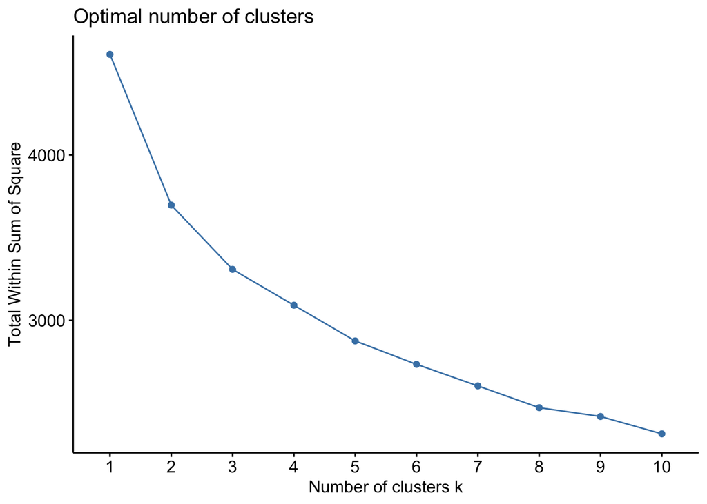

```r
# Within-cluster sum of square method
set.seed(77)
factoextra::fviz_nbclust(clustering_input2, kmeans, method = "wss")
```

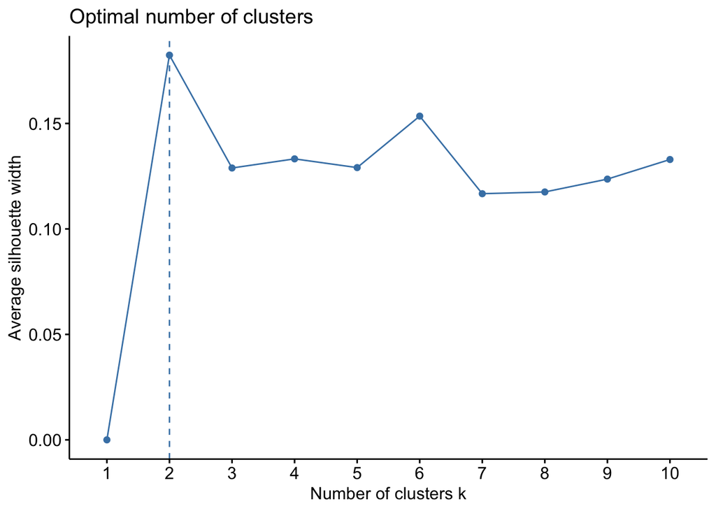

```r
# Silhouette approach
set.seed(77)
factoextra::fviz_nbclust(clustering_input2, kmeans, method = "silhouette")
```

## 3.0 - Run and evaluate k-means

## Run the model

```r
set.seed(77)
clusters <- kmeans(clustering_input2, centers=6, iter.max=10, nstart=10)
```

## Check the size of the k clusters

```r
clusters$size
```

```
## [1] 38 16 41 74 48 40
```

## A matrix indicating the mean values for each feature and cluster combination

```r
clusters$centers
```

```
##         size promo_units_per high_med_gp velocityA_units_per
## 1  0.9730808     -0.96508940   0.9416705          -1.0999058
## 2 -2.0769160      0.20998372  -1.3027639           1.9791388
## 3 -0.4937076     -0.47571554  -0.5933514           0.3385144
## 4  0.3219522      0.02170173   0.1905726          -0.6329434
## 5  0.5418821      0.35512582   0.6126291           0.4247053
## 6 -0.8334802      0.85415068  -0.8530105           0.5675765
##   velocityB_units_per velocityC_units_per velocityD_units_per
## 1          0.71493366         1.122293108          0.94452311
## 2         -1.21351814        -2.054344441         -1.32062712
## 3         -0.50137236        -0.204722528          0.08575534
## 4          0.77630614         0.465663111          0.01292992
## 5         -0.88946447         0.000469068         -0.01792813
## 6         -0.04868204        -0.896639723         -0.45935193
##   velocityNEW_units_per energy_units_per regularBars_units_per gum_units_per
```

[output cut: 27 more lines]

```r
# write.csv(clusters$centers, "clusters.csv") # Writes .csv file for further analysis of clusters
```

## Visualize the clustering

(Uses principal components to collapse the dimensions of the data down to two dimensions)

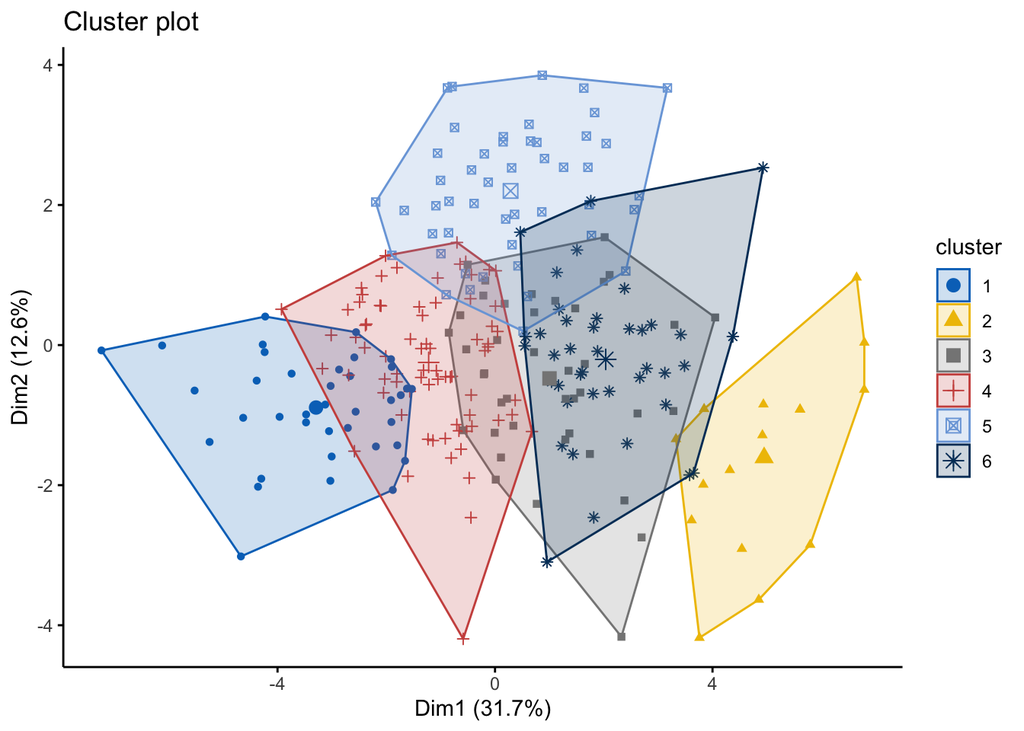

```r
fviz_cluster(clusters, clustering_input2,  geom = "point", show.clust.cent = TRUE, palette = "jco", ggtheme = theme_classic())
```

## 4.0 - put clusters back into the dataset and investigate

## Add clusters to the original, un-standardized dataset and add labels

```r
clustering_input1$cluster <- clusters$cluster

clustering_input1 <- clustering_input1 %>%
        mutate(cluster_labels = case_when(
                cluster==1 ~ 'Large and Profitable',
                cluster==2 ~ 'Small and Not Profitable',
                cluster==3 ~ 'High Gum and Water Sales',
                cluster==4 ~ 'Average Size and Profitability',
                cluster==5 ~ 'Energy Drinks and Potatoes',
                cluster==6 ~ 'High Promo Units',))

slice_sample(clustering_input1, n=10)
```

```
## # A tibble: 10 × 23
##    city          province region    size promo_units_per high_med_gp velocityA_units…
##    <chr>         <chr>    <chr>    <dbl>           <dbl>       <dbl>            <dbl>
##  1 HALIFAX       NS       ATLANTIC  847.           0.392     0.5                0.589
##  2 STRATFORD     ON       ONTARIO   514            0.508     0                  0.659
##  3 LONGUEUIL     QC       QUEBEC    794.           0.415     0.469              0.670
##  4 OTTAWA        ON       ONTARIO   645.           0.378     0.535              0.657
##  5 KELOWNA       BC       WEST      913.           0.381     0.8                0.609
##  6 ST CATHARINES ON       ONTARIO   396.           0.441     0.00641            0.671
##  7 ALDERSYDE     AB       WEST     1046            0.285     1                  0.583
##  8 FORT ST. JOHN BC       WEST      707            0.326     0.635              0.625
##  9 PORT ALBERNI  BC       WEST      985            0.301     1                  0.592
## 10 REPENTIGNY    QC       QUEBEC    810.           0.414     0.780              0.657
## # … with 16 more variables: velocityB_units_per <dbl>,
## #   velocityC_units_per <dbl>, velocityD_units_per <dbl>,
## #   velocityNEW_units_per <dbl>, energy_units_per <dbl>,
## #   regularBars_units_per <dbl>, gum_units_per <dbl>,
## #   bagpegCandy_units_per <dbl>, isotonics_units_per <dbl>,
## #   singleServePotato_units_per <dbl>, takeHomePotato_units_per <dbl>,
## #   kingBars_units_per <dbl>, flatWater_units_per <dbl>, …
```

```r
# Analyze only Parry Sound and Trenton cities.
clustering_input1 %>% slice(156, 225)
```

```
## # A tibble: 2 × 23
##   city        province region   size promo_units_per high_med_gp velocityA_units…
##   <chr>       <chr>    <chr>   <dbl>           <dbl>       <dbl>            <dbl>
## 1 PARRY SOUND ON       ONTARIO   955           0.273           1            0.513
## 2 TRENTON     ON       ONTARIO   351           0.448           0            0.746
## # … with 16 more variables: velocityB_units_per <dbl>,
## #   velocityC_units_per <dbl>, velocityD_units_per <dbl>,
## #   velocityNEW_units_per <dbl>, energy_units_per <dbl>,
## #   regularBars_units_per <dbl>, gum_units_per <dbl>,
## #   bagpegCandy_units_per <dbl>, isotonics_units_per <dbl>,
## #   singleServePotato_units_per <dbl>, takeHomePotato_units_per <dbl>,
## #   kingBars_units_per <dbl>, flatWater_units_per <dbl>, …
```

## 5.0

## Run this code before you start

```r
#install.packages('dbscan') #only install once
library(dbscan)

# read in data (change to your path)
clustering_input1 <- read_rds("city.rds")

# remove store from the data for use later
clustering_input2 <- clustering_input1 %>%
        select(-city, -region, -province)
```

## Standardize the data using z-score standardization.

```r
clustering_input2 <- as.data.frame(scale(clustering_input2))
```

## The analyst has to pick minPts and epsilon

## Use `dbscan::knndistplot()` to find a suitable epsilon.

This plots the k-nearest neighbor distances in a matrix of points. It measures the distance to the k nearest neighbors for each plot. K in this case is the minimum points (minPts) and is selected by the analyst. Then, it sorts those by distance, lowest to highest. This is then the x-axis. On the y-axis, the graph plots the distance to the nearest neighbors for each point.

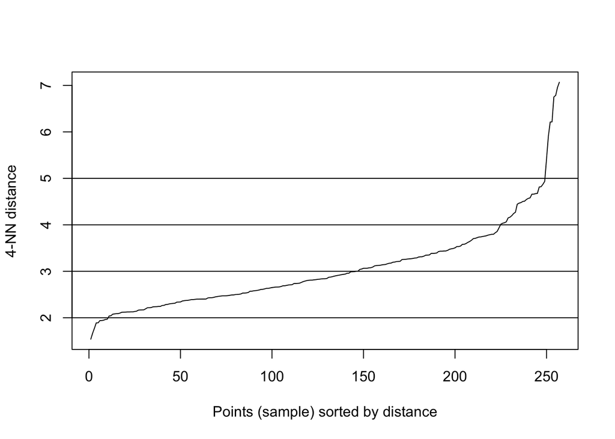

```r
dbscan::kNNdistplot(clustering_input2, k = 4)

# Draw some lines to find the "elbow"
abline(h = c(2, 3, 4, 5))
```

## Use the minPts and epsilon from above to run the DBSCAN algorithm

```r
set.seed(77)
clusters_db <- dbscan::dbscan(clustering_input2, eps = 5, minPts = 4)
```

## Use the `table()` function to print the size of the clusters.

```r
table(clusters_db$cluster)
```

```
##
##   0   1
##   4 253
```

## 6.0 - Visualize the clusters

## Visualize the clusters

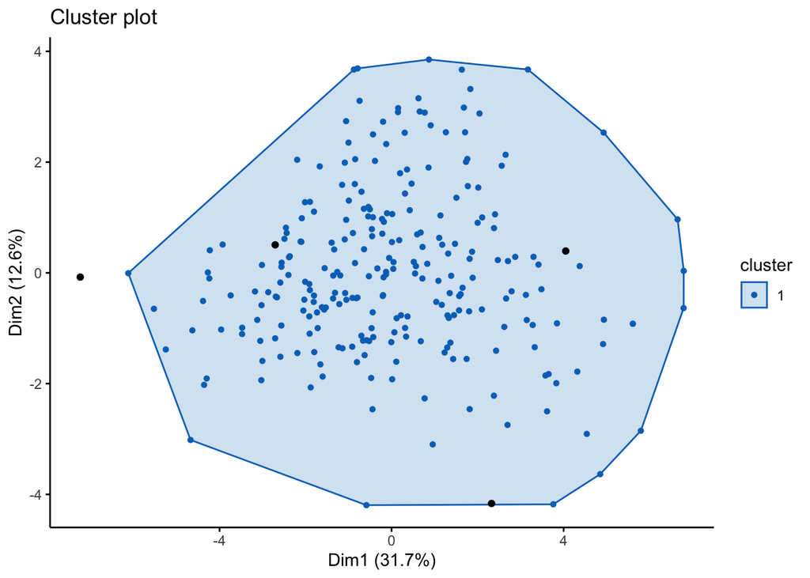

```r
fviz_cluster(clusters_db, clustering_input2,  geom = "point", show.clust.cent = FALSE, palette = "jco", ggtheme = theme_classic())
```

## Questions

### 1. (2 points) How many clusters do you want to use for the K-means algorithm for this data? Play around a bit to make your decision. Justify your answer with evidence from your analysis. Specifically, discuss the following:

### 1.a. results from the “wss” and the “silhouette” methods of finding the optimal number of clusters,

Within the “wss” method, k should be picked at the “elbow” where the next highest k does not decrease wss as much as previously. Following this method, k could be selected between 5 and 8.

### 1.b. the size of clusters, and the two-dimensional cluster plot. There is no right answer here, but clearly defend your responses.

Based on the above conclusions, a cluster size of 6 was selected. At a cluster size of 5, the size of each cluster is 41, 80, 48, 50, and 38. At a cluster size of 6, the size of each cluster is 38, 16, 41, 74, 48, and 40. While these cluster sizes vary more than at k = 5, the two-dimensional plot shows that at k = 6 each cluster appears to have more even deistance around each centroid, compared to 5 or other values.

### 2. (3 points) Regardless of your answer above, use the following code for the `kmeans()` function to answer the rest of the questions about K-means: `kmeans(clustering_input2, centers=6, iter.max=10, nstart=10)`.

### 2.a. Using K-means, print the cluster centers using `clusters$centers` and name each of your clusters and explain how you came up with each name. As you do this, remember that the amounts you see are centered and standardized, so, focus on their sign and size without going into more detail. For example, a title might say something like, “Large; profitable; diverse products; chips and water”. Next, place those cluster names into the `clustering_input1` dataset using the code provided in class.

Clusters are named as follows:

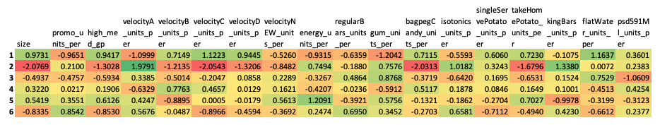

### 2.b. Which number of cluster groups together the cities that are the largest and most profitable?

Cluster 1 groups together cities that are largest and most profitable as the high_med_gp value is largest in this cluster (0.9417).

### 2.c. Provide one recommendation to NANSE based upon this analysis.

Based upon this analysis, NANSE should seek to learn from the ‘Large and Profitable’ cluster in order to determine what drives high profitability and how less profitable stores can model sales characteristics from this group. Additionally, NANSE should consider learning from the ‘Small and Not Profitable’ cluster as it may have something to learn from its high velocity A category in addition to why it remains unprofitable.

### 3. (2 points) After adding your cluster names to `clustering_input1` above in 1a, look at the dataset and describe what you learn about the cities of Trenton and Parry Sound. We did not standardize the data in `clustering_input1`, so this data is easier to interpret following the data description sheet.

Parry Sound is part of the ‘Large and Profitable’ cluster while Trenton is part of the ‘Small and Not Profitable’ cluster. These cluster assignments make sense as Parry Sound appears to have a higher-than-median gross profit (1) and high size at (955) while Trenton does not have a higher-than-median gross profit (0) and lower size (351). While Trenton beats out Parry Sound in velocity category A, Parry Sound beats out Trenton in velocity categories B, C, and D. This may be an area NANSE can look further into as a root cause for Parry Sound’s higher profitability.

### 4. (1 points) Run the DBSCAN algorithm using epsilon = 5 and minPts=4. Print the size of the clusters that this creates. How many clusters are there and how many cities are in each cluster?

There is one cluster with 253 cities. The other 4 cities are outliers.

### 5. (2 points) How does your solution using K-means compare to that using DBSCAN? Specifically, answer the following:

### 5.a. Which is more helpful and why? Which method would you suggest that the management of NANSE use and why?

K-means is more helpful as meaningful clusters are derived through this method. With DBSCAN, only one cluster is produced which does not produce insights NANSE will require to determine how cities are grouped together based on sales history of the stores in those cities. With K-means, it was easy to determine what types of cities are characterized by size, profitability, and other variables. Management of NANSE should utilize the K-means method as this method better solves their business problem and identifies overall differences, reasons for profitability, and other similarities.

### 5.b. How do the methods deal with outliers differently?

DBSCAN can deal with outliers more effectively as it removes outliers from its clusters. K-means still includes outliers in each cluster.